# Access to Government Benefits through the Nonprofit Sector

Kevin Schachter  
Graduate Student, University of Manitoba

# The Problem: Benefit Non-take-up

### Government Benefits Are Critical for Poverty Relief

- 57.6 percent of total income for Canadian residents in the bottom income decile came from government transfers
- Income benefits are prominent in Canada’s First Poverty Reduction Strategy
  - Canada Child Benefit
  - Guaranteed Income Supplement
  - Canada Workers Benefit

Source: Statistics Canada, 2016 Census of Population, Statistics Canada Catalogue no. 98-400-X2016116.

### Many Low-income Canadians Miss Out on Benefits

- 13.7 percent of people aged 15 and over in the bottom income decile did not receive any government transfers
- 4 percent of households in the bottom income decile did not receive any government transfers

Source: Statistics Canada, 2016 Census of Population, Statistics Canada Catalogue nos. 98-400-X2016116 and 98-400-X2016146.

### Benefit Take-up Is Complicated

Accessing government benefits may require:

- Personal income tax filing
- Separate applications (paper or online)
- In-person meetings
- Documentation and personal identification

[figure not shown]

The Problem: Benefit Non-take-up

[figure not shown]

The Problem: Benefit Non-take-up

[figure not shown]

The Problem: Benefit Non-take-up

# The Program: Benefit Intermediary Services

[figure not shown]

The Program: Benefit Intermediary Services

[figure not shown]

The Program: Benefit Intermediary Services

# Case Study: Benefit Intermediaries in Winnipeg

## Research Questions

1. How do benefit intermediary programs promote access to government income benefits in Manitoba?
2. What factors contribute to successful program outcomes?
3. What constraints do these programs face?

# Methodology

## Realist Analysis

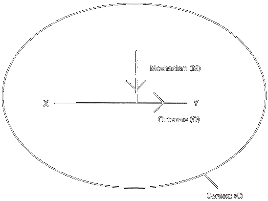

Context-Mechanisms-Outcomes

Ray Pawson, “Theorizing the Interview,” *The British Journal of Sociology* 47, no. 2 (1996): 295–314, doi:10.2307/591728; Ray Pawson and Nick Tilley, *Realistic Evaluation* (Thousand Oaks, CA: SAGE Publications Inc., 1997).

## Insider Research

[figure not shown]

Insider Research

## Methods

- Semi-structured interviews with six key informants
- Review of scholarly and grey literature
- Statistics Canada data tables

# Findings

### Public and Private Supports Are Lacking

#### Public Sector

- “Bureaucratic disentitlement”
- Closure of in-person help desks
- Insufficient call centre capacity
- Offloading to community

#### Private Sector

- May be too costly
- Often don’t specialize in benefits available to low-income community members

Michael Lipsky, “Bureaucratic Disentitlement in Social Welfare Programs,” *Social Service Review* 58, no. 1 (March 1, 1984): 3–27, doi:10.1086/644161.

### Benefit Intermediaries (Partially) Fill This Gap

- Nonprofit organizations and arms-length agencies mediate access to income benefits (affirmation) and work for systemic changes to increase benefit accessibility (nonreformist reform).

Nancy Fraser, “Social Justice in the Age of Identity Politics: Redistribution, Recognition, and Participation,” in *Redistribution or Recognition? A Political-Philosophical Exchange*, by Nancy Fraser and Axel Honneth (New York: Verso, 2003), 7–109.

# Affirmation

### Affirmation: Goals

#### Redistribution

- Benefit intermediaries increase service users’ incomes and enhance quality of life.

#### Recognition

- Benefit intermediaries empower service users to interact with the welfare state from a position of higher status.

Fraser, “Social Justice in the Age of Identity Politics: Redistribution, Recognition, and Participation.”

### Affirmation: Activities

- Financial literacy education and public legal education
- Benefit screening
- Tax return preparation and benefit applications
- Financial problem-solving and coaching
- Advocacy and representation

### Affirmation: Outcomes

#### Redistribution

6 organizations served about 14,000 service users who accessed $38 million of government income benefits in 2018.

#### Recognition

- Greater knowledge and awareness
- Reduced stress
- Increased hope
- Enhanced skills and confidence

> The income support piece is important. … I like to think of it as, it stops the bleeding. It prevents people from falling further into the abyss.

### Affirmation: Key Mechanisms

- Services match community needs
  - Government transfers are important
  - Few options for benefits assistance
  - Benefit intermediaries offer free support
  - Community members trust community service providers
- A recognitive approach to redistribution
  - “Taking the lead from the participant”
  - “Supportive counseling”

> I’m not going to say we’re social workers or anything, but part of the job is – you have to have the ability to listen and let each person know that they’re important. They matter. And that they’re not just another number.

# Nonreformist Reform

### Nonreformist Reform: Goals

- to eliminate structural barriers that inhibit benefit take-up
- to build cross-sectoral capacity to assist low-income community members to access their benefits

#### Immediate Outcome

- Enhance service users’ quality of life.

#### Long-term Impact

- Increase the accessibility of welfare state income benefits.

### Nonreformist Reform: Activities

- Direct service delivery
- Cross-sectoral collaboration
- Public policy advocacy
- Contention: complaints & litigation

### Nonreformist Reform: Observed Outcomes

- Changes to benefit eligibility criteria, regulations, policies, and practices
- Increased investment in public sector and nonprofit benefit assistance services
- A growing field of practice: a “tax empire”

> Well, as soon as we smash capitalism, right, but until then [laughs], I think you can have a big effect by having people who work within those systems have a better understanding of the people who rely on those systems. One piece of it is doing what we can to help people working within those systems operate from a strengths-based approach – what can they do to not just be a needless bureaucracy.

### Nonreformist Reform: Key Mechanisms

- Flexible framing
  - Social justice
  - Cost reduction / return on investment
- Learning from service users
  - Noticing patterns through service delivery
  - Bringing systemic issues to policymakers, politicians, and partners

> This is costly to our system, and so if you don’t believe me that it’s the right thing to do, I’m also going to tell you that this could actually save money.

> The social policy work that we do, that nonprofits do, is really important. Because we have this great resource that governments can learn a great deal from, and that’s our clients.

# Constraints

### Limits of “Third-Party Government”

- “philanthropic insufficiency”
  - not enough resources to meet community need
- “philanthropic paternalism”
  - reliance on state funding limits public policy engagement
- “philanthropic particularism”
  - agencies may target specific demographics, regions, or time periods

Lester M. Salamon, “Of Market Failure, Voluntary Failure, and Third-Party Government: Toward a Theory of Government-Nonprofit Relations in the Modern Welfare State,” *Nonprofit and Voluntary Sector Quarterly* 16, no. 1–2 (January 1, 1987): 29–49, doi:10.1177/089976408701600104.

> The big disadvantage is that we can only be a drop in the bucket. People have to line up. We’ve tried to minimize the impact of people having to navigate our waiting lists and whatever. But it’s still a big hassle for people to have to compete for scarce space with us.

### Benefit Intermediaries Are Part of The “Shadow State”

- They redistribute income by mediating access to welfare state income benefits
- They deliver services that were offloaded from the welfare state
- They rely on state funding to deliver services

Jennifer Wolch, “The Shadow State : Transformations in the Voluntary Sector,” in *The Power of Geography: How Territory Shapes Social Life*, ed. Jennifer R. Wolch and Michael J. Dear (Boston: Unwin Hyman, 1989), 197–221.

> I think it also takes people out of the mainstream. So people are having this sort of particular experience of interacting with big parts of systems that’s like, ‘Oh, this how poor people do this. And this is how everybody else does their taxes.’ … And so I think it’s sort of a disservice. Systems don’t have to adapt to low-income people’s needs if we’re taking on all that.

# Summary

### Benefit Intermediaries

- affirm service users access to welfare state income benefits  
  (redistribution)
- provide opportunities for service users to build esteem  
  (recognition)
- pursue systemic changes to increase benefit accessibility  
  (nonreformist reform)
- face contextual constraints that limit their impact

## Let’s Chat!

- Kevin Schachter
- schachtk@myumanitoba.ca

**Acknowledgements**

This research received generous financial support from the Social Sciences and Humanities Research Council of Canada through The Joseph-Armand Bombardier Canada Graduate Scholarship–Master’s Program and The Manitoba Research Alliance grant, “Partnering for Change – Community-based solutions for Aboriginal and inner-city poverty.” I am also grateful for travel grants from the Canadian Sociological Association and the University of Manitoba.

Icons are from [the Noun Project](https://thenounproject.com): “Ottawa” and “Victoria” by Adam Lin, “Building” by ProSymbols, “Payroll” by Ben Iconator, “Service” and “Group” by Gregor Cresnar, “Accountant” by projecthayat, “Finance” by Delwar Hossain, and “Dollar funding” by Rockicon.